# 5a: Stationarity.tests()

[Nao Mimoto](https://nmimoto.github.io/) - [Dept. of Statistics](http://www.uakron.edu/stat/) : [The University of Akron](http://www.uakron.edu)

[Class Web Page](https://nmimoto.github.io/477/)

## 1. Non-stationary time series

### Daily Price of Dow Jones

```
From Aug. 28 to Dec. 18, 1972 (Brockwell p.153)
```

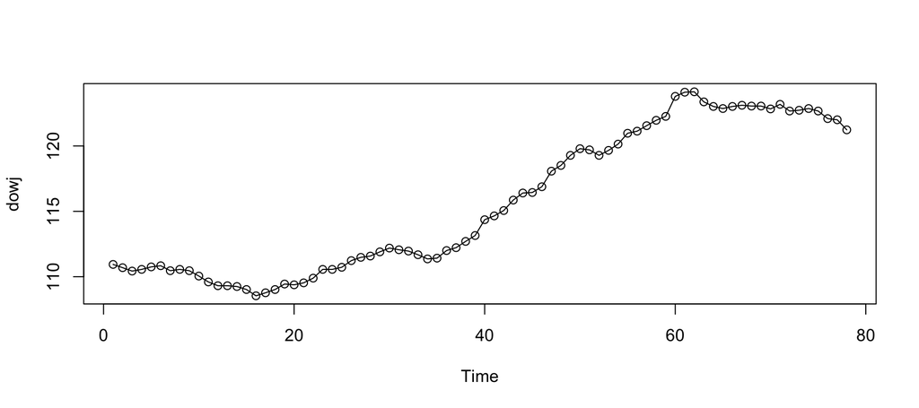

```r
  D = read.csv("https://nmimoto.github.io/datasets/dowj.csv", header=TRUE)
  Dowj  = ts(D, start=1, freq=1)    # turn D into TS object
  plot(Dowj, type="o")               # plot with both line and circle
```

Is this stationary?

### Lake Huron Data

Annual Level of Lake Huron 1875-1972

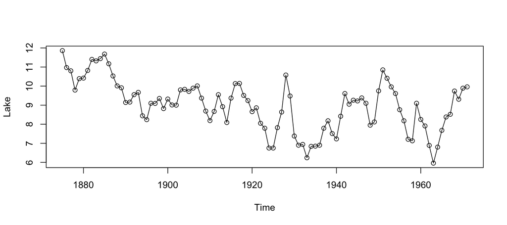

```r
  D = read.csv("https://nmimoto.github.io/datasets/lake.csv", header=TRUE)
  Lake  = ts(D[,1], start=1875,, freq=1)  # turn it into TS object startng year 1875
  plot(Lake, type="o")
```

Is this stationary?

## 2. Tests for Stationarity

How do you check if a time seirs is stationary?

- Visual inspection for constant mean, constant variance
- KPSS test ($H_0$: Stationary)
- ADF test ($H_0$: Not Stationary)
- PP test ($H_0$: Not Stationary)
- Fit AR(1), and see if $\hat \phi_1$ is significantly different from 1.

### KPSS test

Kwiatkowski-Phillips-Schmidt-Shin (1992) test for
$$\left\{
\begin{array}{ll}
H_0: X_t \mbox{ is trend stationary}\\
H_A: X_t \mbox{ is not stationary} \\
\end{array} \right.$$
Large p-value means “Stationary”. This is default choice in **auto.arima()**. Decompose the series as
$$X_t \hspace{3mm} = \hspace{3mm} T_t + W_t + Y_t$$
where $T_t$ is deterministic trend, $W_t$ is random walk, and $Y_t$ is stationary error. Lagrange multiplier test that the random walk has zero variance.

### ADF test

Augumented Dickey-Fuller test (Brockwell p. 194). “Unit-root” test for
$$\left\{
\begin{array}{ll}
H_0: Y_t \mbox{ is not stationary} \\
H_A: Y_t \mbox{ is stationary}
\end{array} \right.$$

Is replaced by
$$\left\{
\begin{array}{ll}
H_0: Y_t \mbox{ has unit root} \\
H_A: Y_t \mbox{ does not have unit root }
\end{array} \right.$$

Small p-value rejects the null hypothesis of non-stationarity, and means “Stationary”.

Fit AR(1) to a time series, and test if $\phi_1$ is significantly different from 1, by
$$\frac{ \hat \phi_1 -1 }{ SE(\hat \phi_1) } \sim N(0,1)$$

### PP test

Phillips-Perron test for the null hypothesis that x has a unit root. Same hypothesis as ADF test.

Small p-value means “Stationary”.

The tests are similar to ADF tests, but they incorporate an automatic correction to the DF procedure to all ow for autocorrelated residuals.

Calculation of the test statistics is complex. The tests usually give the same conclusions as the ADF tests

**P-value of (KPSS, ADF, PP) tests**

(LARGE, small, small) $\to$ All three indicating stationarity.

(small, LARGE, LARGE) $\to$ All three indicating non-stationarity.

(anything else) $\to$ Conflicing conclusions, inconclusive.

## 3. Stationarity.tests()

### Random Sample

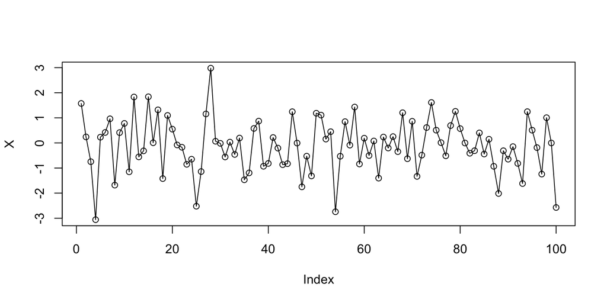

```r
  # load Stationarity.tests() from class web page
  source('https://nmimoto.github.io/R/TS-00.txt')

  # Test it on random sample
  X = rnorm(100)
  plot(X, type="o")
```

```r
  Stationarity.tests(X)
```

```
##        KPSS  ADF   PP
## p-val:  0.1 0.01 0.01
```

Large, small, small $\to$ stationary. As it should be.

### Dow Jones data

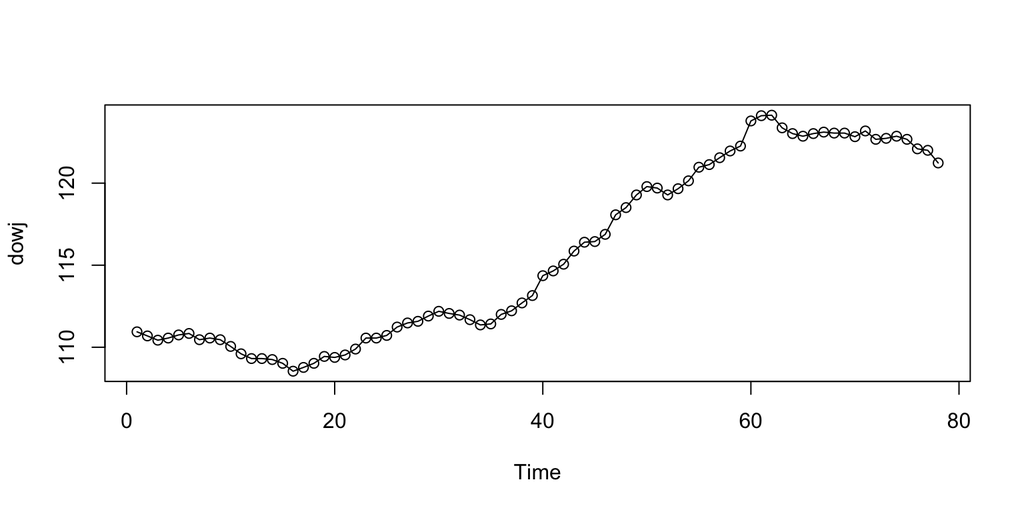

```r
  plot(Dowj, type="o")
```

```r
  Stationarity.tests(Dowj)
```

```
##        KPSS   ADF    PP
## p-val: 0.01 0.655 0.847
```

small, Large, Large $\to$ Not stationary.

### Lake Huron Data

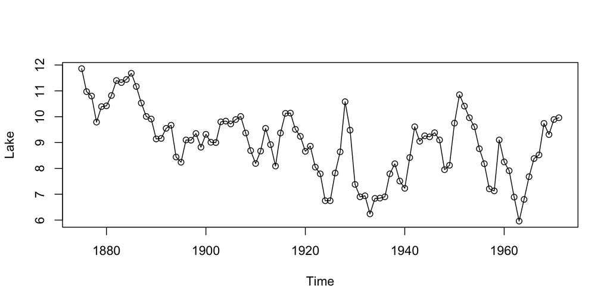

```r
  plot(Lake, type="o")
```

```r
  Stationarity.tests(Lake)
```

```
##        KPSS  ADF    PP
## p-val: 0.01 0.24 0.025
```

small, Large, small $\to$ conflicting. First two is indicating Non-Stationarity, last one is indicating stationarity.